# Project 03

Taylor Ledford

Updated: Tuesday, December 04, 2018 @ 01:08:10 PM

```r
library(tidyverse)
mercury <- read.csv("https://raw.githubusercontent.com/STAT-JET-ASU/Datasets/master/Chihara/FishMercury.csv")
```

### Your Analyses

1. Compute the sample size, mean, standard deviation, median, and 5% trimmed mean for the sample using `summarize` in `dplyr`. Create a boxplot using `ggplot2`. You do not need a title or different axis labels.

```r
mercury <- rename(mercury, "Data" = "Mercury")

mercury %>%
  summarize(n = n(), mean = mean(Data), sd = sd(Data), median = median(Data), trimmed_mean = mean(Data, trim = .05))
```

```
   n      mean        sd median trimmed_mean
1 30 0.1818667 0.3216053  0.129    0.1266786
```

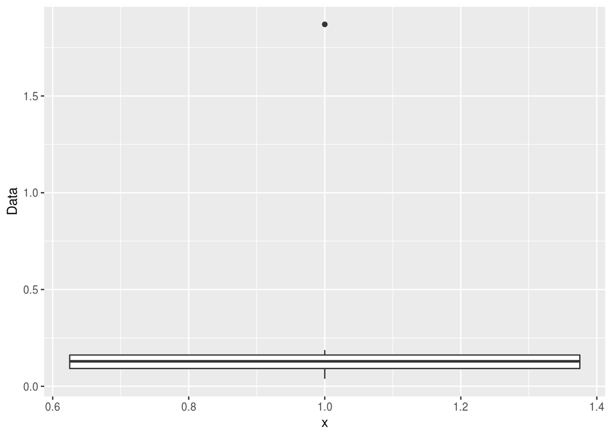

```r
ggplot(mercury, aes(x = 1, y = Data)) +
  geom_boxplot()
```

2. A common rule for determining when we can use the central limit theorem is n ≥ 30. Since that is true in this instance, compute a traditional 95% confidence interval to estimate the true mean level of mercury for this species of fish in the sampled lake.

```r
data <- mercury$Data

n <- length(data)

mean(data) + qt(c(0.025, 0.975), n-1) * sd(data)/sqrt(n)
```

```
[1] 0.06177727 0.30195607
```

3. Compute a bootstrap 95% percentile interval to estimate the true mean level of mercury for this species of fish in the sampled lake. Do not include any plots in this section.

```r
N <- 10^4

bootmean <- numeric(N)
bootsd <- numeric(N)

for (i in 1:N){
  bootsample <- sample(data, n, replace = TRUE)
  bootmean[i] <- mean(bootsample)
  bootsd[i] <- sd(bootsample)
}

quantile(bootmean, c(0.025, 0.975))
```

```
     2.5%     97.5%
0.1121000 0.3059358
```

4. Assess your bootstrap sampling distribution of $\bar{x}$ for normality using a density plot, an ECDF plot, and a quantile-quantile plot. Include red reference curves for the theoretical normal distribution.

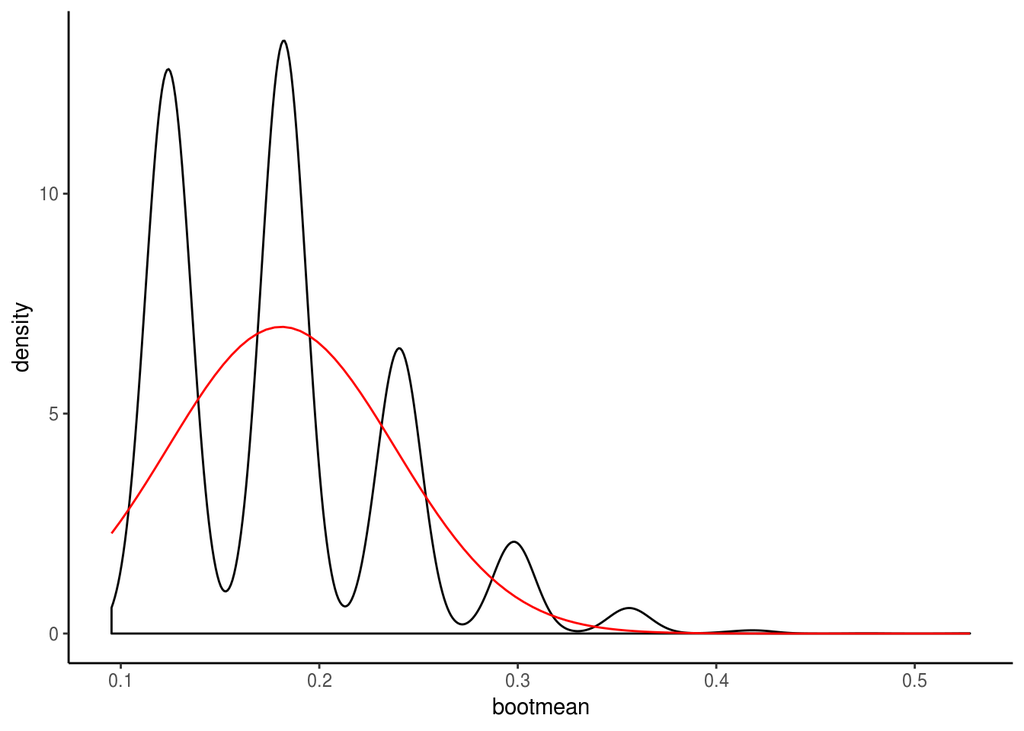

```r
M <- mean(bootmean)
S <- sd(bootmean)

ggplot(NULL, aes(x=bootmean)) +
  geom_density() +
  stat_function(fun = dnorm, args = list(M, S), color = "red") +
  theme_classic()
```

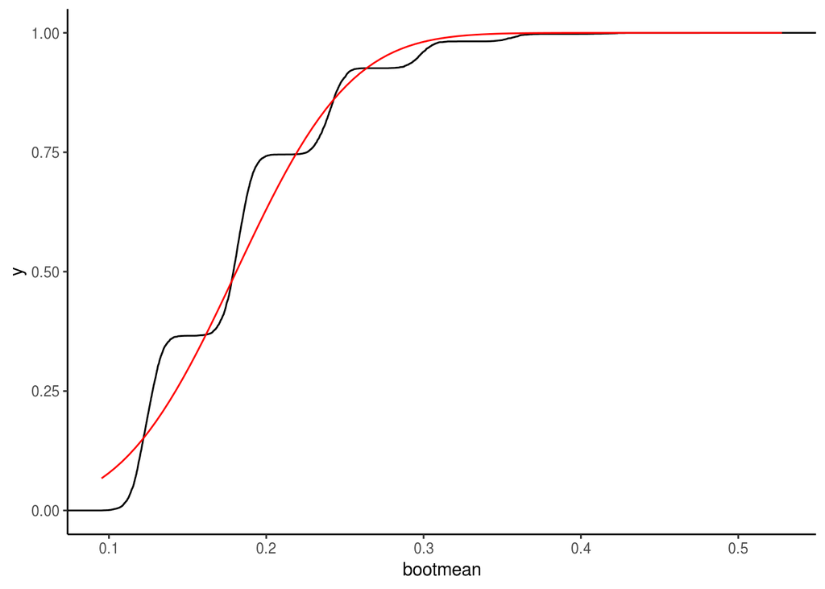

```r
ggplot(NULL, aes(x=bootmean)) +
  stat_ecdf() +
  stat_function(fun = pnorm, args = list(M, S), color = "red") +
  theme_classic()
```

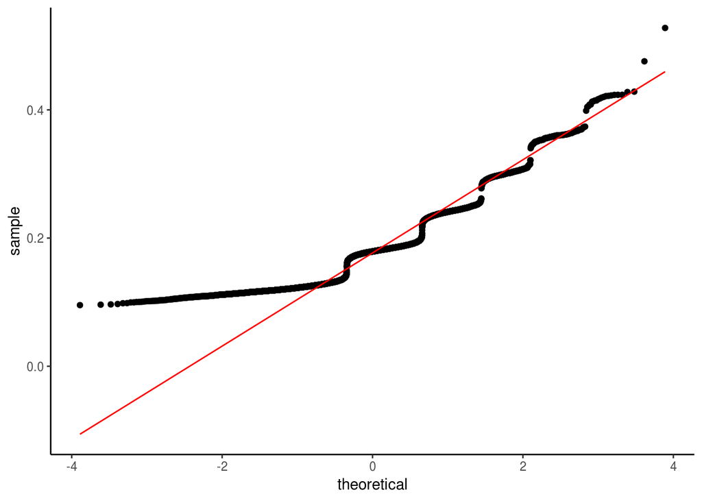

```r
ggplot(NULL, aes(sample = bootmean)) +
  geom_qq() +
  geom_qq_line(color = "red") +
  theme_classic()
```

5. Create an ordered factor variable called `safety` that categorizes fish in the sample as “Best”, “Good”, or “Avoid”. Then create a barplot to display that variable. Include an informative title and axis labels.

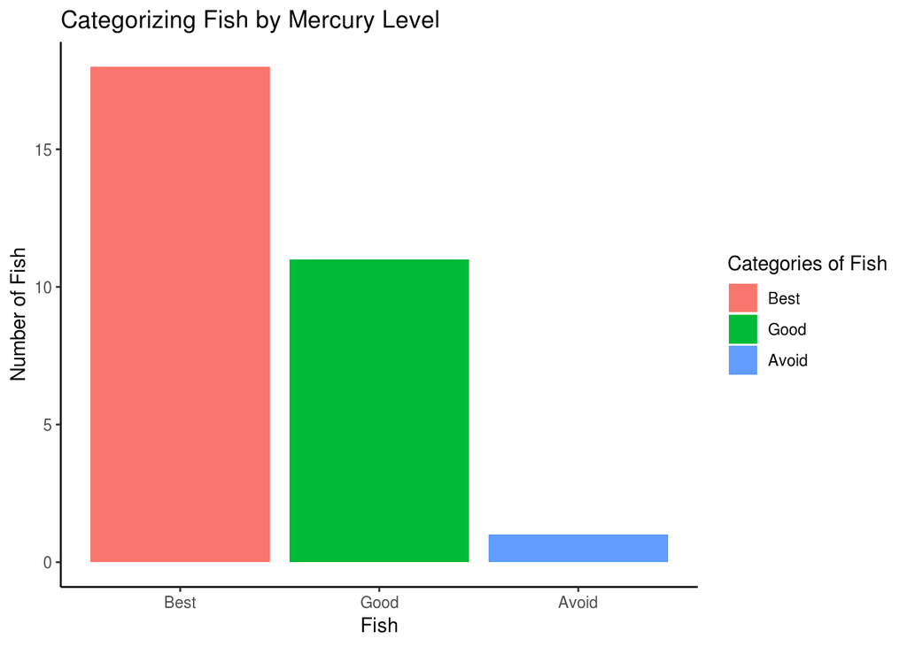

```r
mercury <- mercury %>% mutate(Fish_Category= case_when(data <= 0.15  ~ "Best",
                                                       data <= 0.46 & data > 0.15 ~ "Good",
                                                       data >  0.46 ~ "Avoid"))

levels <- factor(c("Best", "Good", "Avoid"))

mercury$Fish_Category <- ordered(mercury$Fish_Category, levels=levels)

ggplot(mercury, aes(x=Fish_Category, fill=Fish_Category)) +
  geom_bar() +
  labs(x="Fish", y="Number of Fish", title = "Categorizing Fish by Mercury Level") +
  scale_fill_discrete(name = "Categories of Fish") +
  theme_classic()
```

6. Compute a bootstrap 95% percentile interval to estimate the true proportion of this species of fish that fall into the “best” category. Do not include any plots in this section.

```r
mercury <- mercury %>%
  mutate(Category = ifelse(Fish_Category == "Best", "Best", "Not Best"))

levels2 <- factor(c("Best", "Not Best"))

mercury$Category <- ordered(mercury$Category, levels=levels2)

level <- mercury$Category

n <- length(level)
N <- 10^4

bootprop <- numeric(N)

for (i in 1:N){
  bootsample <- sample(level, n, replace = TRUE)
  bootprop[i] <- mean(bootsample == "Best")
}

quantile(bootprop, c(.025,.975))
```

```
     2.5%     97.5%
0.4333333 0.7666667
```

7. Why are your intervals in (2) and (3) different? Is it appropriate to the CLT for this data? Explain using the results of (1) and (4).

ANSWER: The intervals are different in 2 and 3 because one of the requirements of the central limit theorem is that if the underlying distribution is skewed or has outliers the a sample much greater than 30 is needed. This outlier of 1.870 in the data makes the CLT not applicable for this dataset.

8. Assuming this is a representative sample, can we confidently say a majority of all fish of this species in the lake have fewer than 0.15 µg/g of mercury? Why or why not?

ANSWER: I do not think that you can say the majority of fish have fewer than .15. This is because the confidence interval goes from below half, .43, and more than three-fourths, .76.

END PROJECT 3